# Mounting Drive

```python
from google.colab import drive
drive.mount('/content/drive/')
```

```python
path = "path to file"
```

# Importing Libraries

```python
import numpy as np
import pandas as pd
import pandas_profiling
import seaborn as sns

%matplotlib inline
import matplotlib.pyplot as plt
plt.style.use('ggplot')

from ipywidgets import interact

# Supressing the warning messages
import warnings
warnings.filterwarnings('ignore')
```

```python
from sklearn.model_selection import KFold, cross_val_score
from sklearn.linear_model import LogisticRegression
from sklearn.naive_bayes import GaussianNB
from sklearn.svm import SVC
from sklearn.tree import DecisionTreeClassifier
from xgboost.sklearn import XGBClassifier
from sklearn.ensemble import GradientBoostingClassifier
from sklearn.neighbors import KNeighborsClassifier
from sklearn.ensemble import RandomForestClassifier
from sklearn.model_selection import train_test_split
from sklearn import metrics

from sklearn.pipeline import Pipeline, make_pipeline

# Tuning
from sklearn.model_selection import GridSearchCV


# Preprocessing
from sklearn.preprocessing import MinMaxScaler, StandardScaler, Normalizer, Binarizer, LabelEncoder
```

# Importing Data

```python
train = pd.read_csv("Participants_Data_THL/train.csv")
test = pd.read_csv("Participants_Data_THL/test.csv")
print(train.shape)
print(test.shape)
train.tail()
```

```
(42748, 14)
(18321, 14)
```

|  | edible-poisonous | cap-diameter | cap-shape | cap-color | does-bruise-or-bleed | gill-attachment | gill-color | stem-height | stem-width | stem-color | has-ring | ring-type | habitat | season |
| --- | --- | --- | --- | --- | --- | --- | --- | --- | --- | --- | --- | --- | --- | --- |
| 42743 | p | 2.66 | b | n | f | a | n | 8.08 | 2.35 | g | f | f | g | a |
| 42744 | p | 9.18 | x | n | f | x | w | 9.83 | 11.96 | w | f | f | d | u |
| 42745 | e | 3.86 | b | n | f | a | g | 6.51 | 4.45 | g | f | f | d | w |
| 42746 | p | 3.39 | b | n | f | NaN | k | 10.32 | 5.47 | w | t | NaN | g | u |
| 42747 | e | 9.85 | x | p | f | x | w | 9.98 | 24.25 | w | f | f | d | a |

```python
train.columns
```

```
Index(['edible-poisonous', 'cap-diameter', 'cap-shape', 'cap-color',
       'does-bruise-or-bleed', 'gill-attachment', 'gill-color', 'stem-height',
       'stem-width', 'stem-color', 'has-ring', 'ring-type', 'habitat',
       'season'],
      dtype='object')
```

# About Data

- We have 42748 rows and 14 columns in the Training dataset
- We have 18321 rows and 14 columns in the Testing dataset

https://machinehack.com/hackathon/odetocode_predicting_weather_using_alien_fruit_properties/overview

### Overview

Tredence is a data science and AI engineering company focused on solving the last mile problem in analytics. The ‘last mile’ is defined as the gap between insight creation and value realization. Tredence is 1,500-plus employees strong with offices in Foster City, Chicago, London, Toronto and Bangalore, with the largest companies in retail, CPG, hi-tech, telecom, travel and industrials as clients.

### Problem Statement

The year is 2050 and a team of astronauts from all over the world went on a mission to an Exoplanet and discovered a vast amount of life and awesome weather. The scientists began collecting data samples of fruits found in their landing site and were curious by their shape and size. They collected data for more than a solar year of the planet to understand the fruit growing conditions in different weathers.

To analyze data and grow fruits similar to earth, they began transmitting data back to the Earth, however, due to solar radiation, some data got corrupted and got lost in transmission. Back on Earth, the scientists figured they need to identify the type of climate the exoplanet has based on the properties of the fruit with the existing challenge of missing data. Help the scientists identify the earth-like season in which the fruit must have grown using the data collected.

### Data Dictionary:

#### Independent Variables

# Data Cleaning

## Duplicated data

```python
train.duplicated().sum()
```

```
91
```

```python
duplicate_train_data = train[train.duplicated()]
duplicate_train_data.head(10)
```

|  | edible-poisonous | cap-diameter | cap-shape | cap-color | does-bruise-or-bleed | gill-attachment | gill-color | stem-height | stem-width | stem-color | has-ring | ring-type | habitat | season |
| --- | --- | --- | --- | --- | --- | --- | --- | --- | --- | --- | --- | --- | --- | --- |
| 4226 | p | 4.41 | o | g | f | f | f | 0.0 | 0.0 | f | t | f | d | s |
| 5498 | p | 4.41 | o | w | f | NaN | w | 0.0 | 0.0 | f | f | f | d | a |
| 9420 | p | 2.73 | o | g | f | f | f | 0.0 | 0.0 | f | f | f | d | a |
| 9586 | p | 2.76 | o | g | f | f | f | 0.0 | 0.0 | f | f | f | d | w |
| 10613 | p | 3.83 | o | w | f | NaN | w | 0.0 | 0.0 | f | f | f | d | u |
| 12123 | p | 3.16 | o | g | f | f | f | 0.0 | 0.0 | f | f | f | d | u |
| 12466 | p | 2.82 | o | g | f | f | f | 0.0 | 0.0 | f | f | f | d | u |
| 12470 | p | 4.41 | o | w | f | NaN | w | 0.0 | 0.0 | f | f | f | d | a |
| 12667 | p | 4.66 | o | w | f | NaN | w | 0.0 | 0.0 | f | f | f | d | u |
| 15211 | p | 3.15 | o | g | f | f | f | 0.0 | 0.0 | f | f | f | d | w |

```python
print(f"Removing {round((duplicate_train_data.shape[0]*100/train.shape[0]),2)}% of data is affordable")
```

```
Removing 0.21% of data is affordable
```

```python
## we will simply delete the rows with duplicate values
print('Shape before deleting duplicate values:', train.shape)

train.drop_duplicates(inplace=True, keep='first')
print('Shape After deleting duplicate values:', train.shape)
train.reset_index(inplace=True)
```

```
Shape before deleting duplicate values: (42748, 14)
Shape After deleting duplicate values: (42657, 14)
```

```python
## we will simply delete the rows with duplicate values
print('Shape before deleting duplicate values:', test.shape)

test.drop_duplicates(inplace=True, keep='first')
print('Shape After deleting duplicate values:', test.shape)
test.reset_index(inplace=True)
```

```
Shape before deleting duplicate values: (18321, 14)
Shape After deleting duplicate values: (18275, 14)
```

## Handling Missing Values

```python
train.isna().sum()
```

```
index                      0
edible-poisonous           0
cap-diameter               0
cap-shape                  0
cap-color                  0
does-bruise-or-bleed       0
gill-attachment         6910
gill-color                 0
stem-height                0
stem-width                 0
stem-color                 0
has-ring                   0
ring-type               1719
habitat                    0
season                     0
dtype: int64
```

There are two columns having missing values.

1. gill-attachment
2. ring-type

```python
train["gill-attachment"].value_counts()
```

```
a    8874
d    7222
x    5171
p    4205
s    3964
e    3939
f    2372
Name: gill-attachment, dtype: int64
```

Let's check gill-color which seems related to gill-attachment

```python
train["gill-color"].value_counts()
```

```
w    12901
n     6803
y     6707
p     4148
g     2888
f     2372
o     2040
k     1666
r     1002
e      760
b      688
u      682
Name: gill-color, dtype: int64
```

f = none we can see where there is no gill-attachment => no gill-color hence the same count 2372  
gill-color having w, n an y are in large frequency.

```python
train[(train["gill-color"] == "f") & (train["gill-attachment"].isna())].shape
```

```
(0, 15)
```

```python
train[train["gill-attachment"].isna()]["gill-color"].value_counts()
```

```
w    1879
n    1310
k    1056
g     815
y     567
r     293
b     247
e     242
u     202
p     174
o     125
Name: gill-color, dtype: int64
```

gill-color with w, n, k and g have most of nan values for gill-attachment

There is no pattern except this one So we will randomly fill NA values of gill-attachment with a,d,x,p,s,e

```python
fill_list = ['a','d','x','p','s','e']
train['gill-attachment'] = train['gill-attachment'].fillna(pd.Series(np.random.choice(fill_list, size=train.shape[0])))
```

Now let's deal with ring-type

```python
train["ring-type"].value_counts()
```

```
f    33773
e     1703
z     1493
l     1004
r      992
p      877
g      853
m      243
Name: ring-type, dtype: int64
```

Most of the values are f=none  
Let's check has-ring which seems related to ring-type

```python
train["has-ring"].value_counts()
```

```
f    32051
t    10606
Name: has-ring, dtype: int64
```

```python
train[(train["has-ring"] == "f") & (train["ring-type"].isna())].shape
```

```
(0, 15)
```

```python
train[(train["has-ring"] == "t") & (train["ring-type"] == "f")].shape
```

```
(1722, 15)
```

```python
32051+1722
```

```
33773
```

There are 1722 fruits which has ring but its ring type is none

we will replace nan values with "f" = none

```python
train["ring-type"] = train["ring-type"].fillna("f")
```

```python
train.isna().sum()
```

```
index                   0
edible-poisonous        0
cap-diameter            0
cap-shape               0
cap-color               0
does-bruise-or-bleed    0
gill-attachment         0
gill-color              0
stem-height             0
stem-width              0
stem-color              0
has-ring                0
ring-type               0
habitat                 0
season                  0
dtype: int64
```

similarly for test data

```python
test.isna().sum()
```

```
index                       0
edible-poisonous            0
cap-diameter                0
cap-shape                   0
cap-color                   0
does-bruise-or-bleed        0
gill-attachment          2937
gill-color                  0
stem-height                 0
stem-width                  0
stem-color                  0
has-ring                    0
ring-type                 752
habitat                     0
season                  18275
dtype: int64
```

```python
fill_list = ['a','d','x','p','s','e']
test['gill-attachment'] = test['gill-attachment'].fillna(pd.Series(np.random.choice(fill_list, size=test.shape[0])))
test["ring-type"] = test["ring-type"].fillna("f")

# Dropping season column as it is target (variable having all nan values)
test.drop("season", axis=1, inplace=True)
```

# Data Preprocessing

```python
train.nunique().sort_values()
```

```
edible-poisonous            2
does-bruise-or-bleed        2
has-ring                    2
season                      4
cap-shape                   7
gill-attachment             7
ring-type                   8
habitat                     8
cap-color                  12
gill-color                 12
stem-color                 13
stem-height              2083
cap-diameter             2373
stem-width               4252
index                   42657
dtype: int64
```

```python
train.describe().T
```

|  | count | mean | std | min | 25% | 50% | 75% | max |
| --- | --- | --- | --- | --- | --- | --- | --- | --- |
| index | 42657.0 | 21358.812059 | 12340.842560 | 0.00 | 10669.00 | 21354.00 | 32046.00 | 42747.00 |
| cap-diameter | 42657.0 | 6.718913 | 5.207056 | 0.38 | 3.49 | 5.85 | 8.55 | 62.34 |
| stem-height | 42657.0 | 6.594405 | 3.358340 | 0.00 | 4.65 | 5.96 | 7.74 | 33.92 |
| stem-width | 42657.0 | 12.159831 | 10.054032 | 0.00 | 5.23 | 10.16 | 16.55 | 103.91 |

```python
categCols = train.nunique().sort_values()[train.nunique().sort_values() < 15].index.values
categCols
```

```
array(['edible-poisonous', 'does-bruise-or-bleed', 'has-ring', 'season',
       'cap-shape', 'gill-attachment', 'ring-type', 'habitat',
       'cap-color', 'gill-color', 'stem-color'], dtype=object)
```

```python
type(categCols)
```

```
numpy.ndarray
```

```python
for i in categCols:
    print(i , train[i].unique())
```

```
edible-poisonous ['p' 'e']
does-bruise-or-bleed ['t' 'f']
has-ring ['f' 't']
season ['a' 's' 'u' 'w']
cap-shape ['x' 'o' 'c' 'f' 'b' 's' 'p']
gill-attachment ['s' 'f' 'x' 'a' 'e' 'd' 'p']
ring-type ['f' 'p' 'l' 'z' 'g' 'm' 'e' 'r']
habitat ['d' 'l' 'g' 'w' 'm' 'p' 'h' 'u']
cap-color ['n' 'g' 'y' 'p' 'w' 'o' 'l' 'r' 'e' 'b' 'k' 'u']
gill-color ['w' 'f' 'p' 'n' 'g' 'y' 'o' 'k' 'r' 'u' 'b' 'e']
stem-color ['w' 'f' 'k' 'g' 'n' 'o' 'e' 'y' 'p' 'u' 'l' 'r' 'b']
```

```python
categCols = np.delete(categCols, np.where(categCols == "season"))
categCols
```

```
array(['edible-poisonous', 'does-bruise-or-bleed', 'has-ring',
       'cap-shape', 'gill-attachment', 'ring-type', 'habitat',
       'cap-color', 'gill-color', 'stem-color'], dtype=object)
```

```python
for i in categCols:
    le = LabelEncoder()
    print(i)
    train[i+'_new'] = le.fit_transform(train[i])
    test[i+'_new'] = le.transform(test[i])
    print({l: i for i, l in enumerate(le.classes_)})
```

```
edible-poisonous
{'e': 0, 'p': 1}
does-bruise-or-bleed
{'f': 0, 't': 1}
has-ring
{'f': 0, 't': 1}
cap-shape
{'b': 0, 'c': 1, 'f': 2, 'o': 3, 'p': 4, 's': 5, 'x': 6}
gill-attachment
{'a': 0, 'd': 1, 'e': 2, 'f': 3, 'p': 4, 's': 5, 'x': 6}
ring-type
{'e': 0, 'f': 1, 'g': 2, 'l': 3, 'm': 4, 'p': 5, 'r': 6, 'z': 7}
habitat
{'d': 0, 'g': 1, 'h': 2, 'l': 3, 'm': 4, 'p': 5, 'u': 6, 'w': 7}
cap-color
{'b': 0, 'e': 1, 'g': 2, 'k': 3, 'l': 4, 'n': 5, 'o': 6, 'p': 7, 'r': 8, 'u': 9, 'w': 10, 'y': 11}
gill-color
{'b': 0, 'e': 1, 'f': 2, 'g': 3, 'k': 4, 'n': 5, 'o': 6, 'p': 7, 'r': 8, 'u': 9, 'w': 10, 'y': 11}
stem-color
{'b': 0, 'e': 1, 'f': 2, 'g': 3, 'k': 4, 'l': 5, 'n': 6, 'o': 7, 'p': 8, 'r': 9, 'u': 10, 'w': 11, 'y': 12}
```

```python
train.shape , test.shape
```

```
((42657, 25), (18275, 24))
```

```python
le_target = LabelEncoder()
train['season_new'] = le_target.fit_transform(train['season'])
print({l: i for i, l in enumerate(le_target.classes_)})
```

```
{'a': 0, 's': 1, 'u': 2, 'w': 3}
```

```python
list(le_target.inverse_transform([2, 2, 1,0,3]))
```

```
['u', 'u', 's', 'a', 'w']
```

```python
## Dropping the old columns
train.drop(categCols ,axis=1, inplace=True)
test.drop(categCols ,axis=1, inplace=True)
```

```python
train.drop("season" ,axis=1, inplace=True)
```

```python
train.head()
```

|  | index | cap-diameter | stem-height | stem-width | edible-poisonous_new | does-bruise-or-bleed_new | has-ring_new | cap-shape_new | gill-attachment_new | ring-type_new | habitat_new | cap-color_new | gill-color_new | stem-color_new | season_new |
| --- | --- | --- | --- | --- | --- | --- | --- | --- | --- | --- | --- | --- | --- | --- | --- |
| 0 | 0 | 5.75 | 6.13 | 14.93 | 1 | 1 | 0 | 6 | 5 | 1 | 0 | 5 | 10 | 11 | 0 |
| 1 | 1 | 2.27 | 0.00 | 0.00 | 1 | 0 | 0 | 3 | 3 | 1 | 0 | 2 | 2 | 2 | 1 |
| 2 | 2 | 5.59 | 5.47 | 11.27 | 1 | 1 | 0 | 1 | 6 | 1 | 0 | 11 | 7 | 11 | 0 |
| 3 | 3 | 0.74 | 4.33 | 0.98 | 1 | 0 | 0 | 6 | 0 | 1 | 0 | 7 | 5 | 4 | 0 |
| 4 | 4 | 9.60 | 10.84 | 28.52 | 1 | 0 | 0 | 6 | 0 | 1 | 0 | 5 | 10 | 11 | 2 |

# Feature Engineering

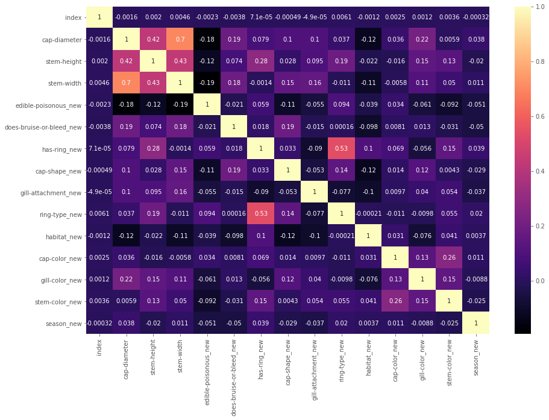

```python
plt.figure(figsize=(15,10))
sns.heatmap(train.corr() , annot=True , cmap = "magma" )
plt.show()
```

# Machine Learning

```python
train.to_csv("train_cleaned.csv")
test.to_csv("test_cleaned.csv")
```

```python
train = pd.read_csv(path+"train_cleaned.csv")
test = pd.read_csv(path+"test_cleaned.csv")

train.reset_index(inplace=True)
test.reset_index(inplace=True)
train.drop(["Unnamed: 0", "level_0", "index"], axis=1 , inplace=True)
test.drop(["Unnamed: 0" ,"level_0", "index"], axis=1 , inplace=True)
print(train.shape)
print(test.shape)
```

```
(42657, 14)
(18275, 13)
```

```python
train.tail()
```

|  | cap-diameter | stem-height | stem-width | edible-poisonous_new | does-bruise-or-bleed_new | has-ring_new | cap-shape_new | gill-attachment_new | ring-type_new | habitat_new | cap-color_new | gill-color_new | stem-color_new | season_new |
| --- | --- | --- | --- | --- | --- | --- | --- | --- | --- | --- | --- | --- | --- | --- |
| 42652 | 2.66 | 8.08 | 2.35 | 1 | 0 | 0 | 0 | 0 | 1 | 1 | 5 | 5 | 3 | 0 |
| 42653 | 9.18 | 9.83 | 11.96 | 1 | 0 | 0 | 6 | 6 | 1 | 0 | 5 | 10 | 11 | 2 |
| 42654 | 3.86 | 6.51 | 4.45 | 0 | 0 | 0 | 0 | 0 | 1 | 0 | 5 | 3 | 3 | 3 |
| 42655 | 3.39 | 10.32 | 5.47 | 1 | 0 | 1 | 0 | 6 | 1 | 1 | 5 | 4 | 11 | 2 |
| 42656 | 9.85 | 9.98 | 24.25 | 0 | 0 | 0 | 6 | 6 | 1 | 0 | 7 | 10 | 11 | 0 |

```python
train.columns
```

```
Index(['cap-diameter', 'stem-height', 'stem-width', 'edible-poisonous_new',
       'does-bruise-or-bleed_new', 'has-ring_new', 'cap-shape_new',
       'gill-attachment_new', 'ring-type_new', 'habitat_new', 'cap-color_new',
       'gill-color_new', 'stem-color_new', 'season_new'],
      dtype='object')
```

```python
X = train.loc[ : , train.columns != 'season_new'].copy() # Churn is our target variable
y = train['season_new'].copy()
```

```python
X
```

|  | cap-diameter | stem-height | stem-width | edible-poisonous_new | does-bruise-or-bleed_new | has-ring_new | cap-shape_new | gill-attachment_new | ring-type_new | habitat_new | cap-color_new | gill-color_new | stem-color_new |
| --- | --- | --- | --- | --- | --- | --- | --- | --- | --- | --- | --- | --- | --- |
| 0 | 5.75 | 6.13 | 14.93 | 1 | 1 | 0 | 6 | 5 | 1 | 0 | 5 | 10 | 11 |
| 1 | 2.27 | 0.00 | 0.00 | 1 | 0 | 0 | 3 | 3 | 1 | 0 | 2 | 2 | 2 |
| 2 | 5.59 | 5.47 | 11.27 | 1 | 1 | 0 | 1 | 6 | 1 | 0 | 11 | 7 | 11 |
| 3 | 0.74 | 4.33 | 0.98 | 1 | 0 | 0 | 6 | 0 | 1 | 0 | 7 | 5 | 4 |
| 4 | 9.60 | 10.84 | 28.52 | 1 | 0 | 0 | 6 | 0 | 1 | 0 | 5 | 10 | 11 |
| ... | ... | ... | ... | ... | ... | ... | ... | ... | ... | ... | ... | ... | ... |
| 42652 | 2.66 | 8.08 | 2.35 | 1 | 0 | 0 | 0 | 0 | 1 | 1 | 5 | 5 | 3 |
| 42653 | 9.18 | 9.83 | 11.96 | 1 | 0 | 0 | 6 | 6 | 1 | 0 | 5 | 10 | 11 |
| 42654 | 3.86 | 6.51 | 4.45 | 0 | 0 | 0 | 0 | 0 | 1 | 0 | 5 | 3 | 3 |
| 42655 | 3.39 | 10.32 | 5.47 | 1 | 0 | 1 | 0 | 6 | 1 | 1 | 5 | 4 | 11 |
| 42656 | 9.85 | 9.98 | 24.25 | 0 | 0 | 0 | 6 | 6 | 1 | 0 | 7 | 10 | 11 |

42657 rows × 13 columns

```python
y
```

```
0        0
1        1
2        0
3        0
4        2
        ..
42652    0
42653    2
42654    3
42655    2
42656    0
Name: season_new, Length: 42657, dtype: int64
```

```python
y.value_counts()
```

```
0    21083
2    16019
3     3679
1     1876
Name: season_new, dtype: int64
```

```python
class_weight = dict({0:1 , 1:11,2:1.3,3:5.7})
class_weight
```

```
{0: 1, 1: 11, 2: 1.3, 3: 5.7}
```

```python
X_train, X_test, y_train, y_test = train_test_split(X, y, test_size=0.30, random_state=42, shuffle=True , stratify=y)

print("The Shape of X_train:", X_train.shape)
print("The Shape of X_test:", X_test.shape)
print("The Shape of y_train:", y_train.shape)
print("The Shape of y_test:", y_test.shape)
print("\n\n---------------------------------------------------------------------------------\n\n")

models = []
models.append(('LogisticRegression', LogisticRegression(random_state=0 , class_weight=class_weight)))
models.append(('GaussianNB'   , GaussianNB()))
# models.append(('SVM'  , SVC(random_state=0 ,probability=True , class_weight=class_weight)))
models.append(('DecisionTreeClassifier', DecisionTreeClassifier(random_state=0 , class_weight=class_weight)))
models.append(('XGBClassifier', XGBClassifier(random_state=0)))
models.append(('GradientBoostingClassifier', GradientBoostingClassifier(random_state=0 )))
models.append(('KNeighborsClassifier', KNeighborsClassifier()))
models.append(('RandomForestClassifier', RandomForestClassifier(random_state=0 , class_weight=class_weight)))


model_name = []
train_accuracy = []
test_accuracy = []

for name, model in models:

    model.fit(X_train,y_train)
    model_name.append(name)
    train_accuracy.append(model.score(X_train, y_train))
    test_accuracy.append(model.score(X_test, y_test))
    print("Done" + name)
Accuracy_df = pd.DataFrame({"Model" : model_name , "train_accuracy" : train_accuracy, "test_accuracy" : test_accuracy})
Accuracy_df
```

```
The Shape of X_train: (29859, 13)
The Shape of X_test: (12798, 13)
The Shape of y_train: (29859,)
The Shape of y_test: (12798,)


---------------------------------------------------------------------------------


DoneLogisticRegression
DoneGaussianNB
DoneDecisionTreeClassifier
DoneXGBClassifier
DoneGradientBoostingClassifier
DoneKNeighborsClassifier
DoneRandomForestClassifier
```

|  | Model | train_accuracy | test_accuracy |
| --- | --- | --- | --- |
| 0 | LogisticRegression | 0.306842 | 0.314190 |
| 1 | GaussianNB | 0.457684 | 0.456478 |
| 2 | DecisionTreeClassifier | 0.998325 | 0.518128 |
| 3 | XGBClassifier | 0.533039 | 0.514377 |
| 4 | GradientBoostingClassifier | 0.545095 | 0.511174 |
| 5 | KNeighborsClassifier | 0.689909 | 0.515159 |
| 6 | RandomForestClassifier | 0.998325 | 0.513596 |

```
                        Model  train_accuracy  test_accuracy
0          LogisticRegression        0.306842       0.314190
1                  GaussianNB        0.457684       0.456478
4  GradientBoostingClassifier        0.545095       0.511174
6      RandomForestClassifier        0.998325       0.513596
3               XGBClassifier        0.533039       0.514377
5        KNeighborsClassifier        0.689909       0.515159
2      DecisionTreeClassifier        0.998325       0.518128
```

```
<BarContainer object of 7 artists>
```

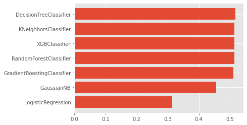

```python
Temp = Accuracy_df.sort_values("test_accuracy")
print(Temp)
plt.barh( Temp["Model"],Temp["test_accuracy"] )
```

```python
def NormalizedModel(nameOfScaler):

    if nameOfScaler == 'standard':
        scaler = StandardScaler()
    elif nameOfScaler =='minmax':
        scaler = MinMaxScaler()
    elif nameOfScaler == 'normalizer':
        scaler = Normalizer()
    elif nameOfScaler == 'binarizer':
        scaler = Binarizer()

    pipelines = []
    pipelines.append((nameOfScaler+'_LR'  , Pipeline([('Scaler', scaler),('LR'  , LogisticRegression(class_weight=class_weight))])))
    pipelines.append((nameOfScaler+'_KNN' , Pipeline([('Scaler', scaler),('KNN' , KNeighborsClassifier())])))
    pipelines.append((nameOfScaler+'_DT'  , Pipeline([('Scaler', scaler),('DT'  , DecisionTreeClassifier(class_weight=class_weight))])))
    pipelines.append((nameOfScaler+'_NB'  , Pipeline([('Scaler', scaler),('NB'  , GaussianNB())])))
    # pipelines.append((nameOfScaler+'_SVM' , Pipeline([('Scaler', scaler),('SVM' , SVC())])))
    pipelines.append((nameOfScaler+'_XGB' , Pipeline([('Scaler', scaler),('XGB' , XGBClassifier())])  ))
    pipelines.append((nameOfScaler+'_GBM' , Pipeline([('Scaler', scaler),('GBM' , GradientBoostingClassifier())])  ))
    pipelines.append((nameOfScaler+'_RF'  , Pipeline([('Scaler', scaler),('RF'  , RandomForestClassifier(class_weight=class_weight))])  ))

    return pipelines

# Train model
def fit_model(X_train, y_train, X_test , y_test ,models):

    num_folds = 10
    scoring = 'accuracy'

    model_name = []
    train_accuracy = []
    test_accuracy = []

    for name, model in models:

        model.fit(X_train,y_train)
        model_name.append(name)
        train_accuracy.append(model.score(X_train, y_train))
        test_accuracy.append(model.score(X_test, y_test))
        print("Done" + name)
        Accuracy_df = pd.DataFrame({"Model" : model_name , "train_accuracy" : train_accuracy, "test_accuracy" : test_accuracy})
    print(Accuracy_df)
    return Accuracy_df
```

```python
ScaledModel = NormalizedModel('standard')
df = fit_model(X_train, y_train, X_test , y_test, ScaledModel)
```

```
Donestandard_LR
Donestandard_KNN
Donestandard_DT
Donestandard_NB
Donestandard_XGB
Donestandard_GBM
Donestandard_RF
          Model  train_accuracy  test_accuracy
0   standard_LR        0.309521       0.315596
1  standard_KNN        0.693091       0.515940
2   standard_DT        0.998325       0.516956
3   standard_NB        0.457684       0.456478
4  standard_XGB        0.533039       0.514377
5  standard_GBM        0.545095       0.511174
6   standard_RF        0.998325       0.510236
```

```
          Model  train_accuracy  test_accuracy
0   standard_LR        0.309521       0.315596
3   standard_NB        0.457684       0.456478
6   standard_RF        0.998325       0.510236
5  standard_GBM        0.545095       0.511174
4  standard_XGB        0.533039       0.514377
1  standard_KNN        0.693091       0.515940
2   standard_DT        0.998325       0.516956
```

```
<BarContainer object of 7 artists>
```

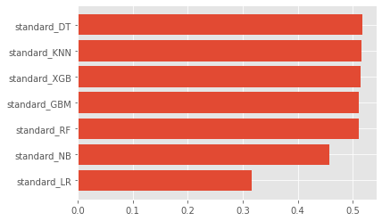

```python
Temp = df.sort_values("test_accuracy")
print(Temp)
plt.barh( Temp["Model"],Temp["test_accuracy"] )
```

```python
ScaledModel = NormalizedModel('minmax')
df = fit_model(X_train, y_train, X_test , y_test, ScaledModel)
```

```
Doneminmax_LR
Doneminmax_KNN
Doneminmax_DT
Doneminmax_NB
Doneminmax_XGB
Doneminmax_GBM
Doneminmax_RF
        Model  train_accuracy  test_accuracy
0   minmax_LR        0.309220       0.315596
1  minmax_KNN        0.691081       0.516331
2   minmax_DT        0.998325       0.518440
3   minmax_NB        0.457684       0.456478
4  minmax_XGB        0.533039       0.514377
5  minmax_GBM        0.545095       0.511095
6   minmax_RF        0.998325       0.512033
```

```
        Model  train_accuracy  test_accuracy
0   minmax_LR        0.309220       0.315596
3   minmax_NB        0.457684       0.456478
5  minmax_GBM        0.545095       0.511095
6   minmax_RF        0.998325       0.512033
4  minmax_XGB        0.533039       0.514377
1  minmax_KNN        0.691081       0.516331
2   minmax_DT        0.998325       0.518440
```

```
<BarContainer object of 7 artists>
```

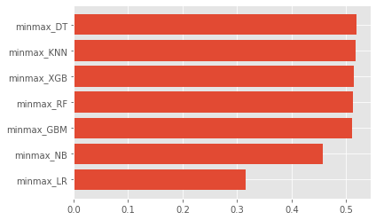

```python
Temp = df.sort_values("test_accuracy")
print(Temp)
plt.barh( Temp["Model"],Temp["test_accuracy"] )
```

```python
ScaledModel = NormalizedModel('normalizer')
df = fit_model(X_train, y_train, X_test , y_test, ScaledModel)
```

```
Donenormalizer_LR
Donenormalizer_KNN
Donenormalizer_DT
Donenormalizer_NB
Donenormalizer_XGB
Donenormalizer_GBM
Donenormalizer_RF
            Model  train_accuracy  test_accuracy
0   normalizer_LR        0.342141       0.337006
1  normalizer_KNN        0.689105       0.513908
2   normalizer_DT        0.998325       0.511642
3   normalizer_NB        0.433806       0.434677
4  normalizer_XGB        0.537995       0.506720
5  normalizer_GBM        0.561707       0.510392
6   normalizer_RF        0.998325       0.514690
```

```
            Model  train_accuracy  test_accuracy
0   normalizer_LR        0.342141       0.337006
3   normalizer_NB        0.433806       0.434677
4  normalizer_XGB        0.537995       0.506720
5  normalizer_GBM        0.561707       0.510392
2   normalizer_DT        0.998325       0.511642
1  normalizer_KNN        0.689105       0.513908
6   normalizer_RF        0.998325       0.514690
```

```
<BarContainer object of 7 artists>
```

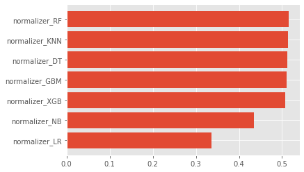

```python
Temp = df.sort_values("test_accuracy")
print(Temp)
plt.barh( Temp["Model"],Temp["test_accuracy"] )
```

```python
finalmodels = []
# pipelines.append((nameOfScaler+'_LR'  , Pipeline([('Scaler', scaler),('LR'  , LogisticRegression())])))

finalmodels.append(('RF' , Pipeline([('RF', RandomForestClassifier(class_weight=class_weight))])))
finalmodels.append(('GBM' , Pipeline([('GBM', GradientBoostingClassifier())])))
finalmodels.append(('KNN' , Pipeline([('KNN', KNeighborsClassifier())])))
finalmodels.append(('DT' , Pipeline([('DT', DecisionTreeClassifier(class_weight=class_weight))])))


finalmodels.append(('Std_RF' , Pipeline([('Scaler' ,StandardScaler()), ('RF', RandomForestClassifier(class_weight=class_weight))])))
finalmodels.append(('std_KNN' , Pipeline([('Scaler' ,StandardScaler()), ('KNN', KNeighborsClassifier())])))
finalmodels.append(('std_DT' , Pipeline([('Scaler' ,StandardScaler()), ('DT', DecisionTreeClassifier(class_weight=class_weight))])))
finalmodels.append(('std_GBM' , Pipeline([('Scaler' ,StandardScaler()), ('GBM', GradientBoostingClassifier())])))

finalmodels.append(('minmax_GBM' , Pipeline([('Scaler' ,MinMaxScaler()), ('GBM', GradientBoostingClassifier())])))
finalmodels.append(('minmax_RF' , Pipeline([('Scaler' ,MinMaxScaler()), ('RF', RandomForestClassifier(class_weight=class_weight))])))
finalmodels.append(('minmax_KNN' , Pipeline([('Scaler' ,MinMaxScaler()), ('KNN', KNeighborsClassifier())])))
finalmodels.append(('minmax_DT' , Pipeline([('Scaler' ,MinMaxScaler()), ('DT', DecisionTreeClassifier(class_weight=class_weight))])))


finalmodels.append(('norm_GBM' , Pipeline([('Scaler' ,Normalizer()), ('GBM', GradientBoostingClassifier())])))
finalmodels.append(('norm_RF' , Pipeline([('Scaler' ,Normalizer()), ('RF', RandomForestClassifier(class_weight=class_weight))])))
finalmodels.append(('norm_KNN' , Pipeline([('Scaler' ,Normalizer()), ('KNN', KNeighborsClassifier())])))
finalmodels.append(('norm_DT' , Pipeline([('Scaler' ,Normalizer()), ('DT', DecisionTreeClassifier(class_weight=class_weight))])))
```

```python
# Metrics
import warnings
warnings.filterwarnings('ignore')
from sklearn.metrics import classification_report
from sklearn.metrics import accuracy_score


# pipeline = make_pipeline(MinMaxScaler(),  LogisticRegression())
for name, model in finalmodels:
    model = model.fit(X_train, y_train)
    y_pred = model.predict(X_test)
    print("\n*****************************************************************************")
    print(name)
    print(f"Training Accuracy Score: {model.score(X_train, y_train) * 100:.1f}%")
    print(f"Validation Accuracy Score :{accuracy_score(y_test, y_pred) * 100:.1f}%")

    print(classification_report(y_test, y_pred))
```

```
RF
Training Accuracy Score: 99.8%
Validation Accuracy Score :51.4%
              precision    recall  f1-score   support

           0       0.56      0.59      0.58      6325
           1       0.41      0.38      0.39       563
           2       0.48      0.47      0.48      4806
           3       0.39      0.33      0.35      1104

    accuracy                           0.51     12798
   macro avg       0.46      0.44      0.45     12798
weighted avg       0.51      0.51      0.51     12798


GBM
Training Accuracy Score: 54.5%
Validation Accuracy Score :51.1%
              precision    recall  f1-score   support

           0       0.54      0.76      0.63      6325
           1       0.64      0.17      0.27       563
           2       0.44      0.32      0.37      4806
           3       0.42      0.09      0.14      1104

    accuracy                           0.51     12798
   macro avg       0.51      0.33      0.35     12798
weighted avg       0.50      0.51      0.47     12798


KNN
Training Accuracy Score: 69.0%
Validation Accuracy Score :51.5%
              precision    recall  f1-score   support

           0       0.56      0.58      0.57      6325
           1       0.39      0.44      0.41       563
           2       0.49      0.48      0.48      4806
           3       0.42      0.33      0.37      1104

```

[output cut: 228 more lines]

```


norm_DT
Training Accuracy Score: 99.8%
Validation Accuracy Score :51.1%
              precision    recall  f1-score   support

           0       0.57      0.57      0.57      6325
           1       0.40      0.41      0.41       563
           2       0.48      0.48      0.48      4806
           3       0.36      0.35      0.35      1104

    accuracy                           0.51     12798
   macro avg       0.45      0.45      0.45     12798
weighted avg       0.51      0.51      0.51     12798
```

# Retraining Model with 100% data & Saving Models as Serilized File

```python
import pickle
import os

for name, model in finalmodels:
    model = model.fit(X, y)
    with open(path + f'{name}_model.pkl', 'wb') as fileWriteStream:
        pickle.dump(model, fileWriteStream)
        # Don't forget to close the filestream!
        fileWriteStream.close()
```

```python
with open(path+'final_models.pkl', 'wb') as fileWriteStream:
        pickle.dump(finalmodels, fileWriteStream)
        # Don't forget to close the filestream!
        fileWriteStream.close()
```

```python
# This Function can be called from any from any front end tool/website
def FunctionPredictResult(InputData):
    import pandas as pd
    Num_Inputs=InputData.shape[0]

    # Generating the input values to the model
    X=InputData.values[0:Num_Inputs]

    import pickle

    with open(path+'final_models.pkl', 'rb') as fileReadStream:
        Final_Models=pickle.load(fileReadStream)
        # Don't forget to close the filestream!
        fileReadStream.close()

    PredictionResult=pd.DataFrame()
    for name, model in Final_Models:
        with open(path+f'{name}_model.pkl', 'rb') as fileReadStream:
            PredictionModel=pickle.load(fileReadStream)
            Prediction=PredictionModel.predict(X)
#             PredictionResult=pd.DataFrame(Prediction, columns=[f'{name}_Pred'])

            PredictionResult[f'{name}_Pred'] = Prediction
        # Don't forget to close the filestream!
            fileReadStream.close()

    return(PredictionResult)
```

```python
# Calling the Function for prediction
Result = FunctionPredictResult(InputData= test)
Result
```

|  | RF_Pred | GBM_Pred | KNN_Pred | DT_Pred | Std_RF_Pred | std_KNN_Pred | std_DT_Pred | std_GBM_Pred | minmax_GBM_Pred | minmax_RF_Pred | minmax_KNN_Pred | minmax_DT_Pred | norm_GBM_Pred | norm_RF_Pred | norm_KNN_Pred | norm_DT_Pred |
| --- | --- | --- | --- | --- | --- | --- | --- | --- | --- | --- | --- | --- | --- | --- | --- | --- |
| 0 | 2 | 0 | 0 | 0 | 2 | 0 | 0 | 0 | 0 | 2 | 0 | 0 | 2 | 0 | 0 | 2 |
| 1 | 2 | 0 | 2 | 2 | 2 | 2 | 2 | 0 | 0 | 2 | 2 | 2 | 0 | 2 | 2 | 0 |
| 2 | 2 | 2 | 2 | 2 | 2 | 2 | 2 | 2 | 2 | 2 | 2 | 2 | 0 | 2 | 2 | 0 |
| 3 | 0 | 2 | 0 | 0 | 2 | 3 | 0 | 2 | 2 | 0 | 3 | 0 | 0 | 0 | 2 | 0 |
| 4 | 0 | 0 | 0 | 2 | 0 | 0 | 2 | 0 | 0 | 0 | 2 | 2 | 0 | 0 | 0 | 0 |
| ... | ... | ... | ... | ... | ... | ... | ... | ... | ... | ... | ... | ... | ... | ... | ... | ... |
| 18270 | 0 | 0 | 0 | 2 | 0 | 0 | 2 | 0 | 0 | 0 | 0 | 2 | 0 | 0 | 0 | 0 |
| 18271 | 0 | 0 | 0 | 0 | 0 | 0 | 0 | 0 | 0 | 0 | 0 | 0 | 0 | 0 | 0 | 0 |
| 18272 | 2 | 0 | 2 | 2 | 2 | 2 | 2 | 0 | 0 | 2 | 2 | 2 | 0 | 0 | 2 | 0 |
| 18273 | 0 | 0 | 0 | 2 | 0 | 0 | 2 | 0 | 0 | 0 | 0 | 2 | 0 | 0 | 0 | 0 |
| 18274 | 2 | 0 | 2 | 0 | 2 | 0 | 0 | 0 | 0 | 2 | 0 | 0 | 2 | 2 | 2 | 0 |

18275 rows × 16 columns

```python
{'a': 0, 's': 1, 'u': 2, 'w': 3}
{0:'a', 1:'s' , 2:'u' , 3:'w'}
```

```python
Final_Result = Result.replace({0:'a', 1:'s' , 2:'u' , 3:'w'})
Final_Result
```

|  | RF_Pred | GBM_Pred | KNN_Pred | DT_Pred | Std_RF_Pred | std_KNN_Pred | std_DT_Pred | std_GBM_Pred | minmax_GBM_Pred | minmax_RF_Pred | minmax_KNN_Pred | minmax_DT_Pred | norm_GBM_Pred | norm_RF_Pred | norm_KNN_Pred | norm_DT_Pred |
| --- | --- | --- | --- | --- | --- | --- | --- | --- | --- | --- | --- | --- | --- | --- | --- | --- |
| 0 | u | a | a | a | u | a | a | a | a | u | a | a | u | a | a | u |
| 1 | u | a | u | u | u | u | u | a | a | u | u | u | a | u | u | a |
| 2 | u | u | u | u | u | u | u | u | u | u | u | u | a | u | u | a |
| 3 | a | u | a | a | u | w | a | u | u | a | w | a | a | a | u | a |
| 4 | a | a | a | u | a | a | u | a | a | a | u | u | a | a | a | a |
| ... | ... | ... | ... | ... | ... | ... | ... | ... | ... | ... | ... | ... | ... | ... | ... | ... |
| 18270 | a | a | a | u | a | a | u | a | a | a | a | u | a | a | a | a |
| 18271 | a | a | a | a | a | a | a | a | a | a | a | a | a | a | a | a |
| 18272 | u | a | u | u | u | u | u | a | a | u | u | u | a | a | u | a |
| 18273 | a | a | a | u | a | a | u | a | a | a | a | u | a | a | a | a |
| 18274 | u | a | u | a | u | a | a | a | a | u | a | a | u | u | u | a |

18275 rows × 16 columns

```python
for name in Final_Result.columns:
    Result[name].to_csv(path+f'results/{name}.csv')
```

```python
X_train.shape
```

```
(29859, 13)
```

```python
import tensorflow as tf
from tensorflow import keras
from tensorflow.keras import Sequential
from tensorflow.keras.layers import Dense
```

```python
# get the model
def get_model(n_inputs, n_outputs):
	model = Sequential()
	model.add(Dense(20, input_dim=n_inputs, kernel_initializer='he_uniform', activation='relu'))
	model.add(Dense(n_outputs, activation='sigmoid'))
	model.compile(optimizer='adam',
              loss='sparse_categorical_crossentropy',
              metrics=['accuracy'])
	return model
```

```python
from sklearn.metrics import accuracy_score
n_inputs, n_outputs = X_train.shape[1], 4
# define evaluation procedure

# define model
model = get_model(n_inputs, n_outputs)
# fit model
model.fit(X_train, y_train, verbose=1, epochs=100)
# make a prediction on the test set
yhat = model.predict(X_test)
# round probabilities to class labels
yhat = yhat.round()
# calculate accuracy
acc = accuracy_score(y_test, yhat)
# store result
print('>%.3f' % acc)
```

[output not shown]

```python
yhat.shape
```

```
(12798, 4)
```

```python
np.argmax(yhat[5])
```

```
0
```